# Parallelogramm

## Das Parallelogramm

### Allgemeines

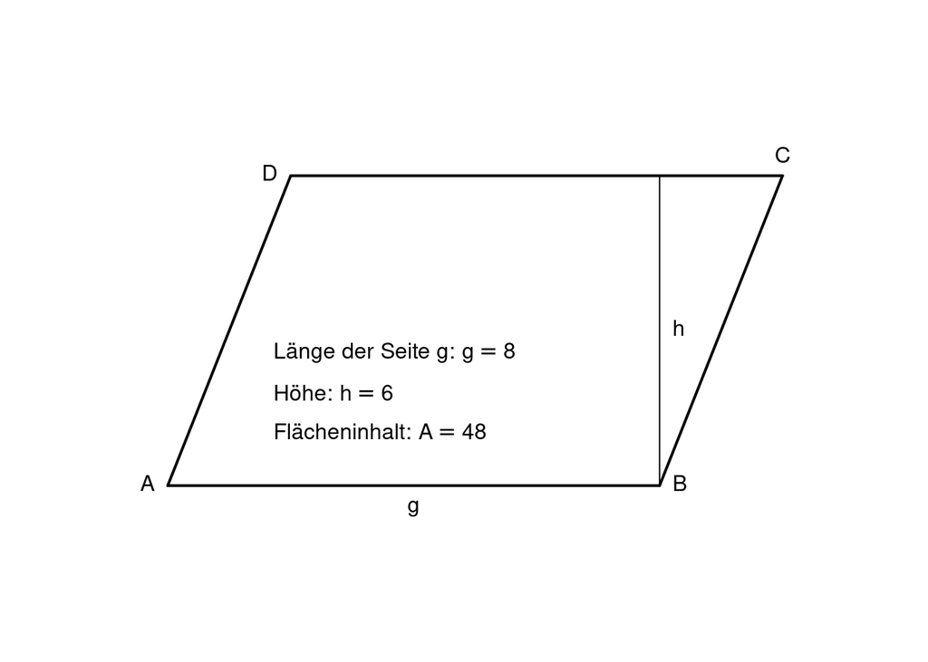

**Flächeninhalt des Parallelogramms:**

$$A = g \cdot h$$

**Umfang des Parallelogramms**
$$U = a + b + c + d$$

**Was heißt das doch gleich?**

Hier einmal in Worten: Den Flächeninhalt $A$ eines Parallelogramms erhältst du, indem du die Länge der Höhe $h$ mit der Länge der Grundseite $g$ multiplizierst. Dabei ist es wichtig, dass die Höhe und die Grundseite auch “zusammengehören”. Die Höhe $h$ im obigen Beispiel gehört zur Grundseite $g$, weil sie auf dieser senkrecht steht.

Hier geht es zurück zur [**Startseite**](https://gdischinger.github.io/Mathe_8d/03FormelnErstellen/20210118/FlächenberechnungErinnerung.html).

### Aufgabe 1

**Berechne die fehlende Größe des Parallelogramms.**

|  | a) | b) | c) |
| --- | --- | --- | --- |
| Grundseite g | 5 cm |  | 90 mm |
| Höhe h | 3 cm | 25 cm |  |
| Flächeninhalt A |  | 625 cm² | 72 cm² |

Hier geht es zurück zur [**Startseite**](https://gdischinger.github.io/Mathe_8d/03FormelnErstellen/20210118/FlächenberechnungErinnerung.html).

### Lösung 1

**Die fehlende Größe des Parallelogramms lautet:**

[output not shown]

**Rechnungen:**

$$\begin{align} a) \quad\quad A &= g \cdot h \\
{}\\
A &= 5 cm \cdot 3 cm = 15 cm² \quad \end{align}$$

$$\begin{align} b) \quad\quad A\quad &= g \cdot h \\
{}\\
625 cm² &= g \cdot 25cm \quad\quad | : 25 cm\\
{}\\
25 cm &= g \end{align}$$

$$\begin{align} c) \quad\quad A\quad &= g \cdot h \\
{}\\
72 cm² &= 90mm \cdot h\\
{}\\
72 cm² &= 9cm \cdot h \quad\quad |:9cm\\
{}\\
8cm &= h \end{align}$$

Hier geht es zurück zur [**Startseite**](https://gdischinger.github.io/Mathe_8d/03FormelnErstellen/20210118/FlächenberechnungErinnerung.html).

### Aufgabe 2

Frau Dischinger behauptet:

> “Der Flächeninhalt eines Parallelogramms ändert sich nicht, wenn man eine Grundseite halbiert und die zugehörige Höhe verdoppelt.”

Stimmt das? Begründe deine Antwort.

Hier geht es zurück zur [**Startseite**](https://gdischinger.github.io/Mathe_8d/03FormelnErstellen/20210118/FlächenberechnungErinnerung.html).

### Lösung 2

Frau Dischinger behauptet:

> “Der Flächeninhalt eines Parallelogramms ändert sich nicht, wenn man eine Grundseite halbiert und die zugehörige Höhe verdoppelt.”

Stimmt das? **Ja, das stimmt!**

Begründung:

Die Grundseite $g$ wird halbiert, das heißt man erhält eine neue Grundseite $g_{neu}$, die halb so lang ist, wie die alte Grundseite $g$, also: $g_{neu}={1 \over 2} \cdot g$. Gleichzeitig wird die Höhe $h$ verdoppelt, das heißt man erhält eine neue Höhe $h_{neu}$, die zweimal so lang ist, wie die alte Höhe $h$, also $h_{neu}= 2 \cdot h$.

Damit ergibt sich für den neuen Flächeninhalt:
$$\begin{align} A_{neu} &= g_{neu} \cdot h_{neu} = \\
{}\\
& = {1 \over 2} \cdot g \cdot 2 \cdot h =\\
{}\\
& = {1 \over 2} \cdot 2 \cdot g \cdot h =\\
{}\\
&= g \cdot h = A \end{align}$$

Hier geht es zurück zur [**Startseite**](https://gdischinger.github.io/Mathe_8d/03FormelnErstellen/20210118/FlächenberechnungErinnerung.html).